# bellabeat_EDA

Deni

1/30/2022

### About BellaBeat

- A high-tech company that manufactures health-focused smart products.
- BellaBeat collects data on activity, sleep, stress, and reproductive health to empower women with knowledge about their own health and habits.
- Founded in 2013, Bellabeat has grown rapidly and quickly positioned itself as a tech-driven wellness company for woman.

### BellaBeat Products

- Bellabeat app: The Bellabeat app provides users with health data related to their activity, sleep, stress, menstrual cycle, and mindfulness habits. This data can help users better understand their current habits and make healthy decisions. The Bellabeat app connects to their line of smart wellness products.
- Leaf: Bellabeat’s classic wellness tracker can be worn as a bracelet, necklace, or clip. The Leaf tracker connects to the Bellabeat app to track activity, sleep, and stress.
- Time: This wellness watch combines the timeless look of a classic timepiece with smart technology to track user activity, sleep, and stress. The Time watch connects to the Bellabeat app to provide you with insights into your daily wellness.
- Spring: This is a water bottle that tracks daily water intake using smart technology to ensure that you are appropriately hydrated throughout the day. The Spring bottle connects to the Bellabeat app to track your hydration levels.
- Bellabeat membership: Bellabeat also offers a subscription-based membership program for users. Membership gives users 24/7 access to fully personalized guidance on nutrition, activity, sleep, health and beauty, and mindfulness based on their lifestyle and goals.

##### Stakeholders

- Urška Sršen: Bellabeat’s cofounder and Chief Creative Officer
- Sando Mur: Mathematician and Bellabeat’s cofounder; key member of the Bellabeat executive team
- Bellabeat marketing analytics team

#### Business Task for this Case Study:

- Analyze smart device usage data in order gain insight into how consumers use non-Bellabeat smart devices.
- Then select one product to apply these insights to.

#### Questions to answer:

- What are some trends that can be found in smart device usage?
- How could we apply these trends to Bellabeat customers?
- How could these trends influence Bellabeats marketing strategy?

Data set used for this EDA https://www.kaggle.com/arashnic/fitbit.

First we will be installing and loading the required R packages.

```r
library(tidyverse)
```

```r
library(dplyr)
library(readr)
library(ggplot2)
library(tidyr)
```

## Dive into the datasets

```r
daily_Activity_merged <- read_csv('dailyActivity_merged.csv')
daily_Calories_merged <- read_csv('dailyCalories_merged.csv')
daily_Steps_merged <- read_csv('dailySteps_merged.csv')
daily_sleep_merged <- read_csv('sleepDay_merged.csv')
```

#### Get an Idea of what data is kept inside each set.

```r
head(daily_Activity_merged)
```

```
## # A tibble: 6 x 15
##        Id ActivityDate TotalSteps TotalDistance TrackerDistance LoggedActivitie~
##     <dbl> <chr>             <dbl>         <dbl>           <dbl>            <dbl>
## 1  1.50e9 4/12/2016         13162          8.5             8.5                 0
## 2  1.50e9 4/13/2016         10735          6.97            6.97                0
## 3  1.50e9 4/14/2016         10460          6.74            6.74                0
## 4  1.50e9 4/15/2016          9762          6.28            6.28                0
## 5  1.50e9 4/16/2016         12669          8.16            8.16                0
## 6  1.50e9 4/17/2016          9705          6.48            6.48                0
## # ... with 9 more variables: VeryActiveDistance <dbl>,
## #   ModeratelyActiveDistance <dbl>, LightActiveDistance <dbl>,
## #   SedentaryActiveDistance <dbl>, VeryActiveMinutes <dbl>,
## #   FairlyActiveMinutes <dbl>, LightlyActiveMinutes <dbl>,
## #   SedentaryMinutes <dbl>, Calories <dbl>
```

```r
head(daily_Calories_merged)
```

```
## # A tibble: 6 x 3
##           Id ActivityDay Calories
##        <dbl> <chr>          <dbl>
## 1 1503960366 4/12/2016       1985
## 2 1503960366 4/13/2016       1797
## 3 1503960366 4/14/2016       1776
## 4 1503960366 4/15/2016       1745
## 5 1503960366 4/16/2016       1863
## 6 1503960366 4/17/2016       1728
```

```r
head(daily_Steps_merged)
```

```
## # A tibble: 6 x 3
##           Id ActivityDay StepTotal
##        <dbl> <chr>           <dbl>
## 1 1503960366 4/12/2016       13162
## 2 1503960366 4/13/2016       10735
## 3 1503960366 4/14/2016       10460
## 4 1503960366 4/15/2016        9762
## 5 1503960366 4/16/2016       12669
## 6 1503960366 4/17/2016        9705
```

```r
head(daily_sleep_merged)
```

```
## # A tibble: 6 x 5
##           Id SleepDay          TotalSleepRecor~ TotalMinutesAsle~ TotalTimeInBed
##        <dbl> <chr>                        <dbl>             <dbl>          <dbl>
## 1 1503960366 4/12/2016 12:00:~                1               327            346
## 2 1503960366 4/13/2016 12:00:~                2               384            407
## 3 1503960366 4/15/2016 12:00:~                1               412            442
## 4 1503960366 4/16/2016 12:00:~                2               340            367
## 5 1503960366 4/17/2016 12:00:~                1               700            712
## 6 1503960366 4/19/2016 12:00:~                1               304            320
```

We can add a new column to daily_sleep_merged where we can see how much time is spent in bed but not asleep by creating a new column named Time_Spent_Awake_in_Bed by subtracting TotalTimeInBed by TotalMinutesAsleep.

```r
daily_sleep_merged <- daily_sleep_merged %>% mutate(Time_Spent_Awake_In_Bed = daily_sleep_merged$TotalTimeInBed - daily_sleep_merged$TotalMinutesAsleep)
head(daily_sleep_merged)
```

```
## # A tibble: 6 x 6
##           Id SleepDay          TotalSleepRecor~ TotalMinutesAsle~ TotalTimeInBed
##        <dbl> <chr>                        <dbl>             <dbl>          <dbl>
## 1 1503960366 4/12/2016 12:00:~                1               327            346
## 2 1503960366 4/13/2016 12:00:~                2               384            407
## 3 1503960366 4/15/2016 12:00:~                1               412            442
## 4 1503960366 4/16/2016 12:00:~                2               340            367
## 5 1503960366 4/17/2016 12:00:~                1               700            712
## 6 1503960366 4/19/2016 12:00:~                1               304            320
## # ... with 1 more variable: Time_Spent_Awake_In_Bed <dbl>
```

We can also see that the SleepDay column contains the time as well. We should seperate each day and time into two different columns.

```r
daily_sleep_merged <- daily_sleep_merged %>% separate(SleepDay, c("Date", "Time"), " ")
head(daily_sleep_merged)
```

```
## # A tibble: 6 x 7
##           Id Date      Time     TotalSleepRecor~ TotalMinutesAsl~ TotalTimeInBed
##        <dbl> <chr>     <chr>               <dbl>            <dbl>          <dbl>
## 1 1503960366 4/12/2016 12:00:00                1              327            346
## 2 1503960366 4/13/2016 12:00:00                2              384            407
## 3 1503960366 4/15/2016 12:00:00                1              412            442
## 4 1503960366 4/16/2016 12:00:00                2              340            367
## 5 1503960366 4/17/2016 12:00:00                1              700            712
## 6 1503960366 4/19/2016 12:00:00                1              304            320
## # ... with 1 more variable: Time_Spent_Awake_In_Bed <dbl>
```

##### Find common columns between each of the datasets.

```r
colnames(daily_Activity_merged)
```

```
##  [1] "Id"                       "ActivityDate"
##  [3] "TotalSteps"               "TotalDistance"
##  [5] "TrackerDistance"          "LoggedActivitiesDistance"
##  [7] "VeryActiveDistance"       "ModeratelyActiveDistance"
##  [9] "LightActiveDistance"      "SedentaryActiveDistance"
## [11] "VeryActiveMinutes"        "FairlyActiveMinutes"
## [13] "LightlyActiveMinutes"     "SedentaryMinutes"
## [15] "Calories"
```

```r
colnames(daily_Calories_merged)
```

```
## [1] "Id"          "ActivityDay" "Calories"
```

```r
colnames(daily_sleep_merged)
```

```
## [1] "Id"                      "Date"
## [3] "Time"                    "TotalSleepRecords"
## [5] "TotalMinutesAsleep"      "TotalTimeInBed"
## [7] "Time_Spent_Awake_In_Bed"
```

```r
colnames(daily_Steps_merged)
```

```
## [1] "Id"          "ActivityDay" "StepTotal"
```

We see a common trait between each data set and that each of them contain an “ID” column. Now I will check to see how many unique sets of ID’s there are.

```r
n_distinct(daily_Activity_merged$Id)
```

```
## [1] 33
```

```r
n_distinct(daily_Calories_merged$Id)
```

```
## [1] 33
```

```r
n_distinct(daily_sleep_merged$Id)
```

```
## [1] 24
```

```r
n_distinct(daily_Steps_merged$Id)
```

```
## [1] 33
```

We see that we have 33 Unique Id’s from DailyActivity, DailyCalories, and DailySteps datasets. While we only have 24 Unique Id’s from the DailySleep dataset.

With an unequal amount of Id’s I will check to see if there are any duplicates in the DailyActivity, DailyCalories, and DailySteps datasets.

```r
nrow(daily_Activity_merged[duplicated(daily_Activity_merged),])
```

```
## [1] 0
```

```r
nrow(daily_Calories_merged[duplicated(daily_Calories_merged),])
```

```
## [1] 0
```

```r
nrow(daily_Steps_merged[duplicated(daily_Steps_merged),])
```

```
## [1] 0
```

We find a result of no duplicates in each dataset. I will now check if DailySleep has any duplicates

```r
nrow(daily_sleep_merged[duplicated(daily_sleep_merged),])
```

```
## [1] 3
```

We find 3 duplicated rows in the dataset. I will now create a new dataframe without the 3 duplicated rows.

```r
daily_sleep_merged_cleaned <- unique(daily_sleep_merged)
nrow(daily_sleep_merged_cleaned[duplicated(daily_sleep_merged_cleaned),])
```

```
## [1] 0
```

### Now we Analyze the data

- By gathering statistical data from each dataset.

```r
head(daily_Activity_merged)
```

```
## # A tibble: 6 x 15
##        Id ActivityDate TotalSteps TotalDistance TrackerDistance LoggedActivitie~
##     <dbl> <chr>             <dbl>         <dbl>           <dbl>            <dbl>
## 1  1.50e9 4/12/2016         13162          8.5             8.5                 0
## 2  1.50e9 4/13/2016         10735          6.97            6.97                0
## 3  1.50e9 4/14/2016         10460          6.74            6.74                0
## 4  1.50e9 4/15/2016          9762          6.28            6.28                0
## 5  1.50e9 4/16/2016         12669          8.16            8.16                0
## 6  1.50e9 4/17/2016          9705          6.48            6.48                0
## # ... with 9 more variables: VeryActiveDistance <dbl>,
## #   ModeratelyActiveDistance <dbl>, LightActiveDistance <dbl>,
## #   SedentaryActiveDistance <dbl>, VeryActiveMinutes <dbl>,
## #   FairlyActiveMinutes <dbl>, LightlyActiveMinutes <dbl>,
## #   SedentaryMinutes <dbl>, Calories <dbl>
```

```r
#we want total steps, totaldistance, VeryActiveMinutes, LightlyActiveMinutes, SedentaryMinutes, and Calories.
daily_Activity_merged %>%
  select(TotalSteps, TotalDistance, VeryActiveMinutes, LightlyActiveMinutes, SedentaryMinutes, Calories) %>%
    summary()
```

```
##    TotalSteps    TotalDistance    VeryActiveMinutes LightlyActiveMinutes
##  Min.   :    0   Min.   : 0.000   Min.   :  0.00    Min.   :  0.0
##  1st Qu.: 3790   1st Qu.: 2.620   1st Qu.:  0.00    1st Qu.:127.0
##  Median : 7406   Median : 5.245   Median :  4.00    Median :199.0
##  Mean   : 7638   Mean   : 5.490   Mean   : 21.16    Mean   :192.8
##  3rd Qu.:10727   3rd Qu.: 7.713   3rd Qu.: 32.00    3rd Qu.:264.0
##  Max.   :36019   Max.   :28.030   Max.   :210.00    Max.   :518.0
##  SedentaryMinutes    Calories
##  Min.   :   0.0   Min.   :   0
##  1st Qu.: 729.8   1st Qu.:1828
##  Median :1057.5   Median :2134
##  Mean   : 991.2   Mean   :2304
##  3rd Qu.:1229.5   3rd Qu.:2793
##  Max.   :1440.0   Max.   :4900
```

#### Daily Activity Statistics

Next we take a look at the statistics from the daily calorie set.

```r
head(daily_Calories_merged)
```

```
## # A tibble: 6 x 3
##           Id ActivityDay Calories
##        <dbl> <chr>          <dbl>
## 1 1503960366 4/12/2016       1985
## 2 1503960366 4/13/2016       1797
## 3 1503960366 4/14/2016       1776
## 4 1503960366 4/15/2016       1745
## 5 1503960366 4/16/2016       1863
## 6 1503960366 4/17/2016       1728
```

```r
summary(daily_Calories_merged)
```

```
##        Id            ActivityDay           Calories
##  Min.   :1.504e+09   Length:940         Min.   :   0
##  1st Qu.:2.320e+09   Class :character   1st Qu.:1828
##  Median :4.445e+09   Mode  :character   Median :2134
##  Mean   :4.855e+09                      Mean   :2304
##  3rd Qu.:6.962e+09                      3rd Qu.:2793
##  Max.   :8.878e+09                      Max.   :4900
```

#### Daily Calories Statistics

- We see that the maximum amount of calories gained from the 33 participants are 4,900 calories gained in a day.
- While the average is 2,304.
- With an average of 2,000 calories needed daily for the average human we can say that the average person in this dataset are achieving their daily calories.

Now onto the daily steps Statistics

```r
head(daily_Steps_merged)
```

```
## # A tibble: 6 x 3
##           Id ActivityDay StepTotal
##        <dbl> <chr>           <dbl>
## 1 1503960366 4/12/2016       13162
## 2 1503960366 4/13/2016       10735
## 3 1503960366 4/14/2016       10460
## 4 1503960366 4/15/2016        9762
## 5 1503960366 4/16/2016       12669
## 6 1503960366 4/17/2016        9705
```

```r
summary(daily_Steps_merged)
```

```
##        Id            ActivityDay          StepTotal
##  Min.   :1.504e+09   Length:940         Min.   :    0
##  1st Qu.:2.320e+09   Class :character   1st Qu.: 3790
##  Median :4.445e+09   Mode  :character   Median : 7406
##  Mean   :4.855e+09                      Mean   : 7638
##  3rd Qu.:6.962e+09                      3rd Qu.:10727
##  Max.   :8.878e+09                      Max.   :36019
```

#### Daily Steps Statistics

- We see a Maximum of 36,019 steps gathered in one day. We can conclulde that, the person who achieved that many steps in a day is very active.
- The average steps in a day is 7,638.

Now onto the daily sleep dataset.

```r
head(daily_sleep_merged_cleaned)
```

```
## # A tibble: 6 x 7
##           Id Date      Time     TotalSleepRecor~ TotalMinutesAsl~ TotalTimeInBed
##        <dbl> <chr>     <chr>               <dbl>            <dbl>          <dbl>
## 1 1503960366 4/12/2016 12:00:00                1              327            346
## 2 1503960366 4/13/2016 12:00:00                2              384            407
## 3 1503960366 4/15/2016 12:00:00                1              412            442
## 4 1503960366 4/16/2016 12:00:00                2              340            367
## 5 1503960366 4/17/2016 12:00:00                1              700            712
## 6 1503960366 4/19/2016 12:00:00                1              304            320
## # ... with 1 more variable: Time_Spent_Awake_In_Bed <dbl>
```

```r
daily_sleep_merged_cleaned %>% select(Id, TotalSleepRecords, TotalMinutesAsleep, TotalTimeInBed, Time_Spent_Awake_In_Bed) %>% summary()
```

```
##        Id            TotalSleepRecords TotalMinutesAsleep TotalTimeInBed
##  Min.   :1.504e+09   Min.   :1.00      Min.   : 58.0      Min.   : 61.0
##  1st Qu.:3.977e+09   1st Qu.:1.00      1st Qu.:361.0      1st Qu.:403.8
##  Median :4.703e+09   Median :1.00      Median :432.5      Median :463.0
##  Mean   :4.995e+09   Mean   :1.12      Mean   :419.2      Mean   :458.5
##  3rd Qu.:6.962e+09   3rd Qu.:1.00      3rd Qu.:490.0      3rd Qu.:526.0
##  Max.   :8.792e+09   Max.   :3.00      Max.   :796.0      Max.   :961.0
##  Time_Spent_Awake_In_Bed
##  Min.   :  0.00
##  1st Qu.: 17.00
##  Median : 25.50
##  Mean   : 39.31
##  3rd Qu.: 40.00
##  Max.   :371.00
```

#### Daily Sleep Statistics

- We gathered that the most amount of sleep gained by an individual was 796 minutes which converts to a little over 13 hours!
- While the average time spent asleep is 419 minutes which converts to 7 hours.
- We gathered that the most time spent awake in bed is 371 minutes which converts to 6 hours.
- While the average time spent awake in bed is 39 minutes.

## Onto Visualizing the Data.

- First we will visualize the dailyActivity dataset to showcase how many calories each person had burned compared to how many steps they took.

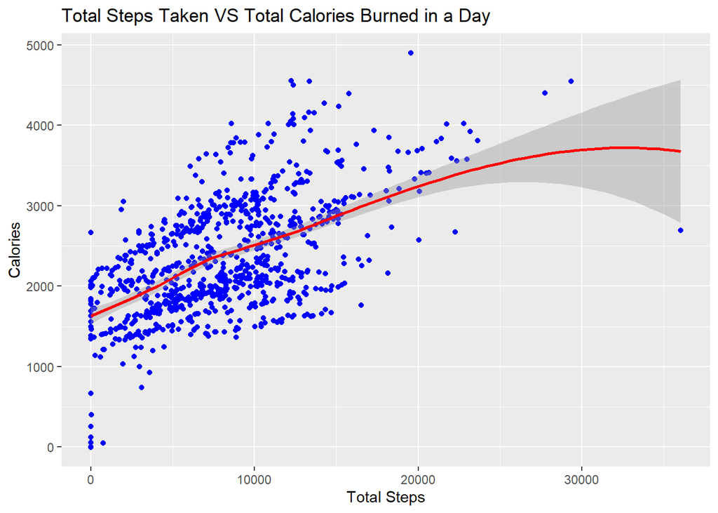

```r
ggplot(data = daily_Activity_merged) + geom_jitter(mapping = aes(x = TotalSteps, y = Calories), color = 'blue') +
  geom_smooth(mapping = aes(x = TotalSteps, y = Calories), color = "red") +
  labs(title = "Total Steps Taken VS Total Calories Burned in a Day", x = "Total Steps", Y = "Calories")
```

The graph above shows the correlation between the total amount of steps taken compared to the total amount of calories burned. We can gather the fact that the more steps that are taken that the more calories are burned.

Now lets check the relationship between sedentary minutes and calories burned.

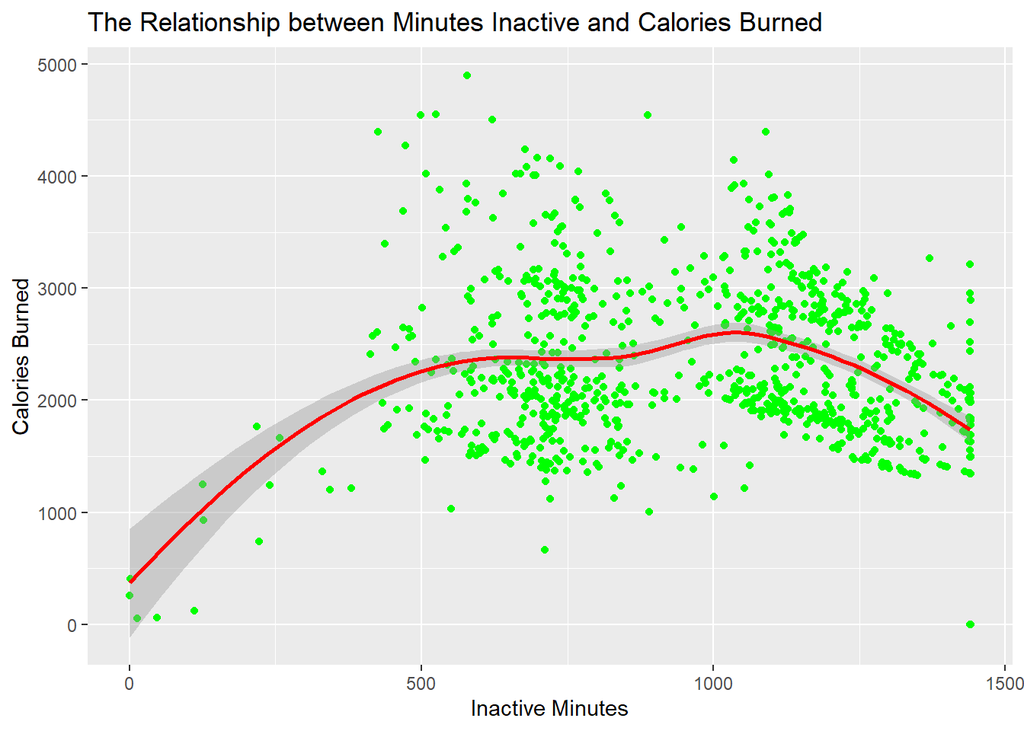

```r
ggplot(data = daily_Activity_merged) + geom_jitter(mapping = aes(x = SedentaryMinutes, y = Calories), color = "Green") +
  geom_smooth(mapping = aes(x = SedentaryMinutes, y = Calories), color = "Red") +
  labs(title = "The Relationship between Minutes Inactive and Calories Burned", x = "Inactive Minutes", y = "Calories Burned")
```

Now lets compare Time Spent awake in Bed and Total Minutes Asleep

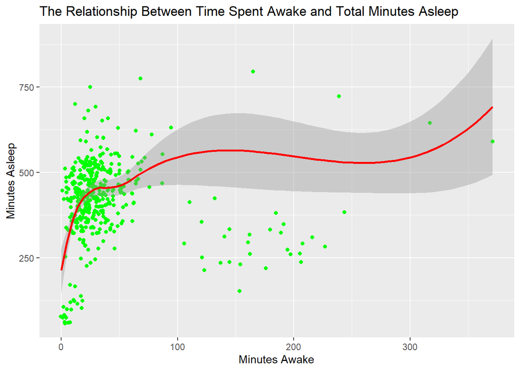

```r
ggplot(data = daily_sleep_merged_cleaned) + geom_jitter(mapping = aes(x = Time_Spent_Awake_In_Bed, y = TotalMinutesAsleep), color = 'green') +
  geom_smooth(mapping = aes(x = Time_Spent_Awake_In_Bed, y = TotalMinutesAsleep), color = 'red') +
  labs(title = "The Relationship Between Time Spent Awake and Total Minutes Asleep", x = 'Minutes Awake', y = 'Minutes Asleep')
```

### Changes to BellaBeat’s marketing strategy based off of the trend we found in the DataSets.

- Based off the results received from the data, users burn more calories the more minutes they’re active. So, Bellabeat should showcase this data to their users to be more active through notifications.
- As well as showcase this data to their users who are more active by congratulating them when they have had daily active streaks.
- And allow users to set daily goals for total steps taken in a day or total calories burned within a day.
- I would apply these insights to the bellabeat app which could improve the amount of user downloads and daily user activity throughout the app.